# Sistem za izposojo koles Capital Bikeshare

Drugi graf nas že malce preseneti. Čeprav nečlani skupaj opravijo manj voženj, se v povprečju vozijo dlje časa. Zanimivo je, da se je, navkljub upadu voženj v letih 2020 in 2021, skupni čas izposoje povečal. Ugibamo, da so ljudje namesto avtobusa in ostalih potniških storitev za daljše prevoze posegli po kolesu pa čeprav manjkrat. Morda so si kolo izposodili za daljše rekreacijske vožnje in ne za vsakodnevne vožnje v službo.

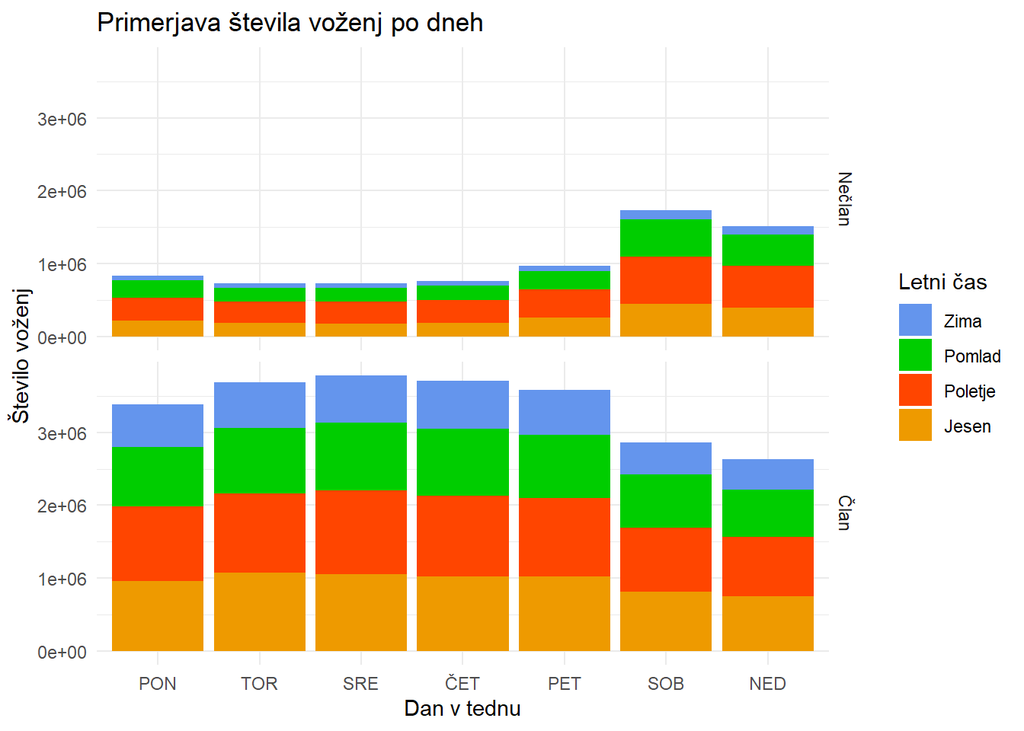

Ker člani kolesarijo več v času delavnika sklepamo, da uporabljajo kolesa predvsem za vsakodnevni prevoz na delo. Nečlani pa ga uporabljajo bolj priložnostno in rekreacijsko.

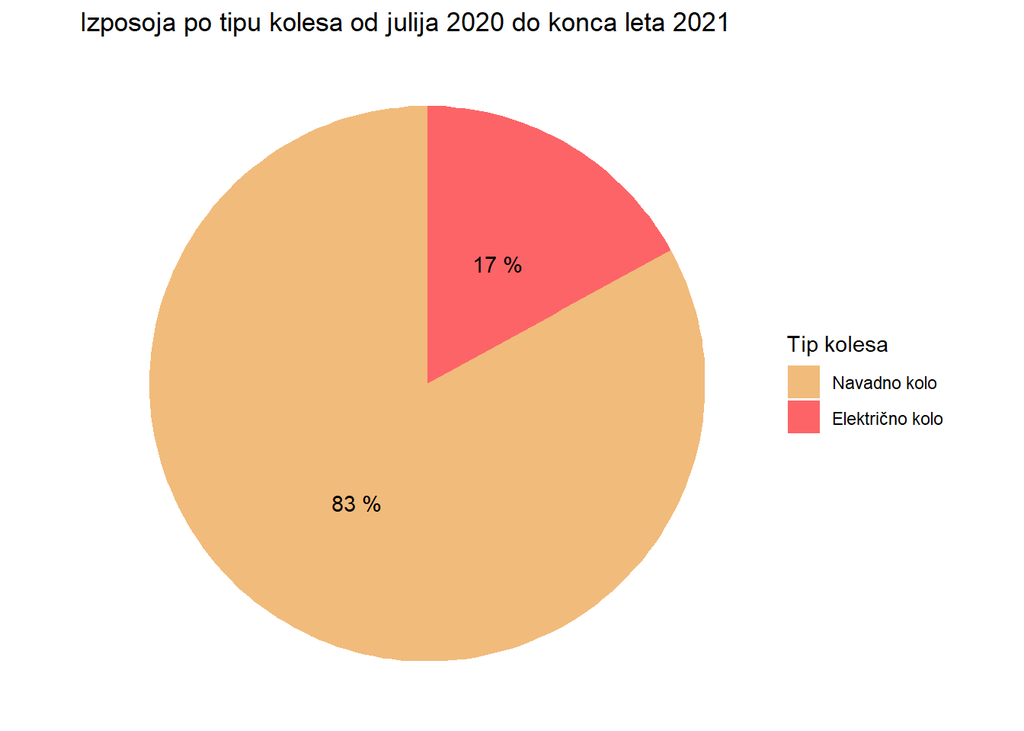

Električna kolesa se prvič pojavijo v mesecu Juliju 2020. V prihodnje bi bilo zanimivo opazovati rast uporabe električnih koles.

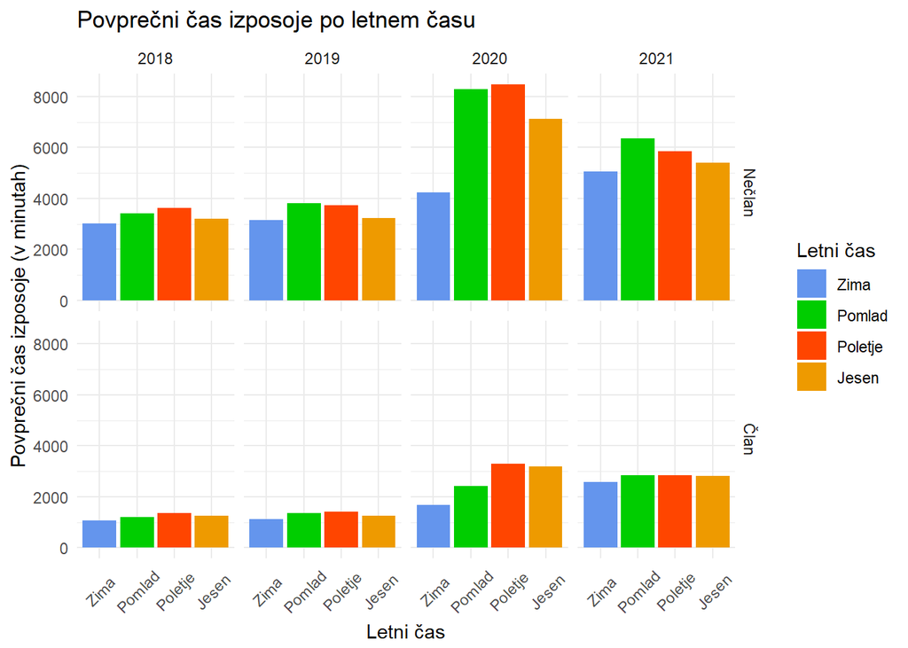

Osredotočimo se na zadnja štiri leta. Pričakovano je povprečni čas vožnje višji za nečlane kot za člane. Člani se tudi obnašajo bolj konsistentno skozi vse letne čase.

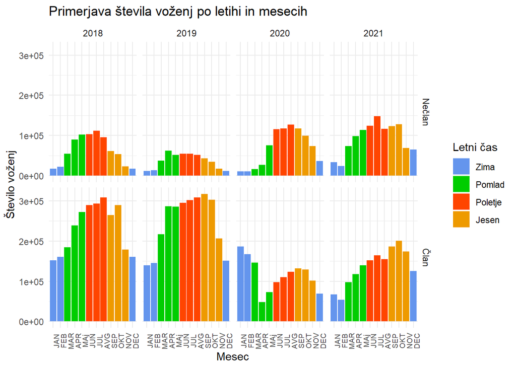

### Pandemija

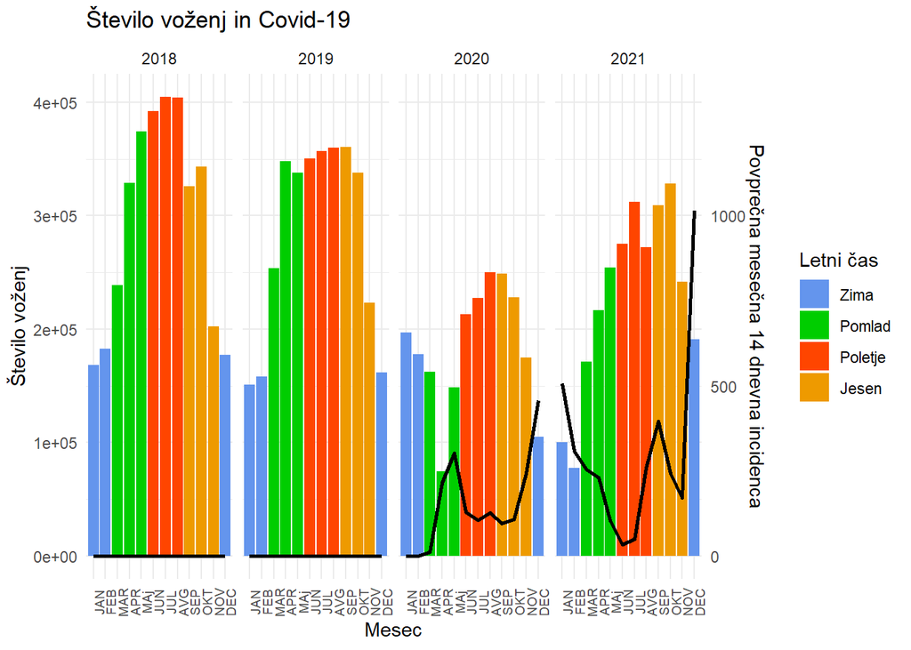

### Vreme

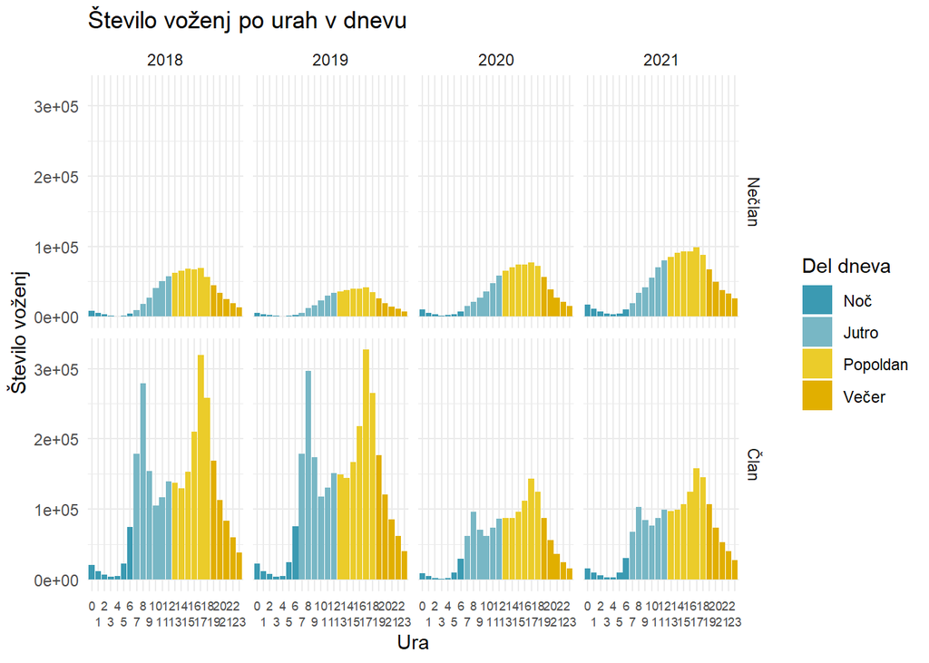

Graf ponovno pokaže, da je delitev glede na tip naročnine zelo pomembna, saj se različna tipa uporabnikov obnašata različno. Kot smo špekulirali že prej, člani opravijo največ voženj ravno v času jutranje in popoldanske gneče, saj so najverjetneje na poti v službo. Nečlani pa so bolj aktivni popoldne in zvečer, v času socialnih aktivnosti. Zdaj lahko z večjim prepričanjem trdimo, da je Covid-19 močneje vplival na člane kot na nečlane.

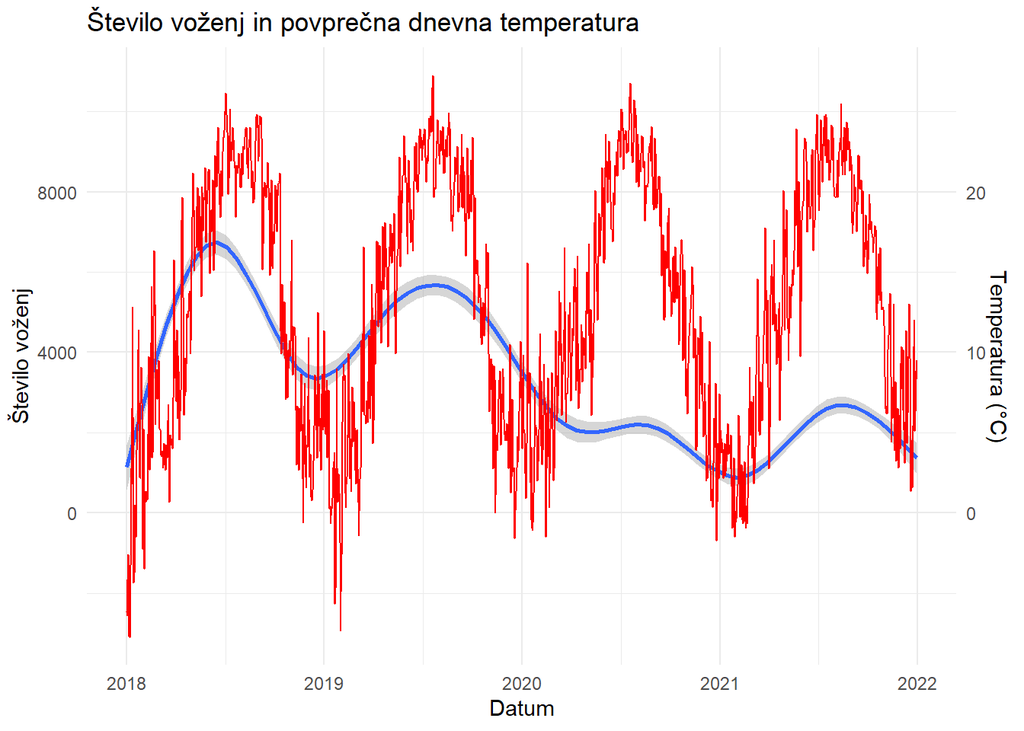

Če pogledamo še vremenski vpliv, pričakovano opazimo, da je število voženj močno povezano s temperaturo. Že prej smo opazili, da letni čas močno vpliva na število voženj, zato je smiselno, da se več voženj opravi pri višjih temperaturah, saj sta letni čas in povprečna dnevna temperatura močno povezana.

### Postaje

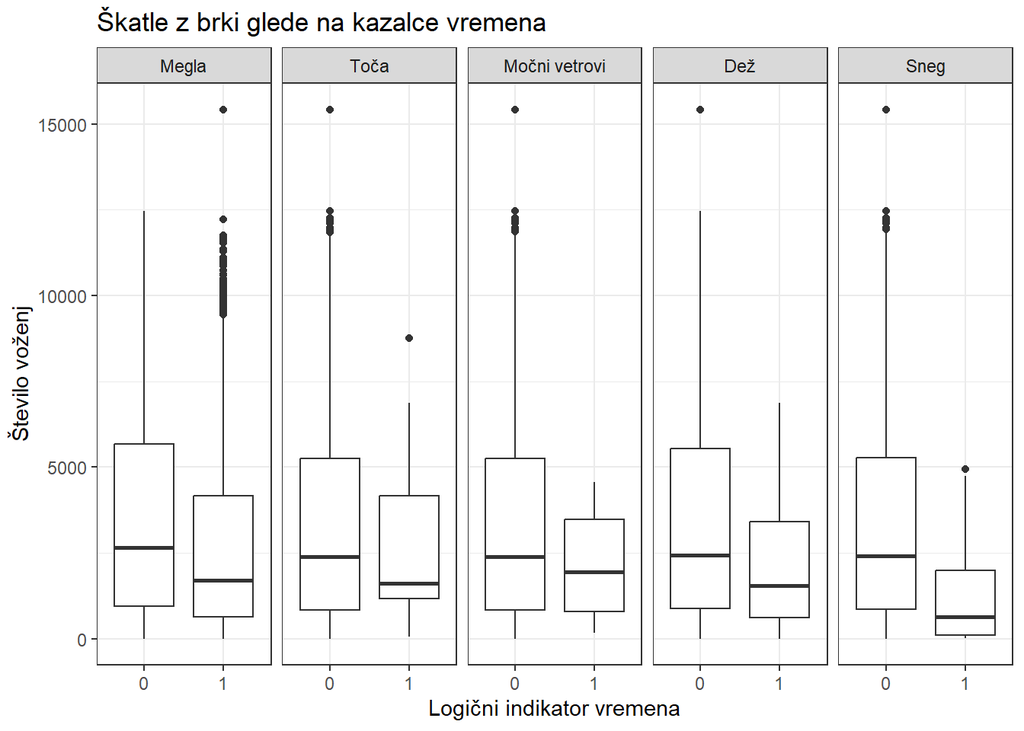

Poleg temperature imajo tudi ostali vremenski dejavniki nezanemarljiv vpliv. V splošnem lepše, kot je vreme, več izposoj je opravljenih.

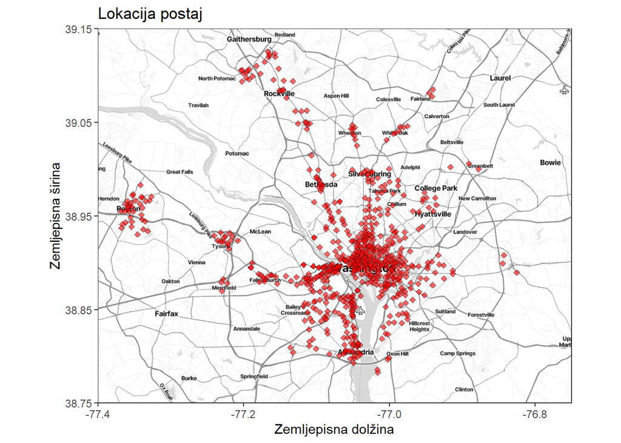

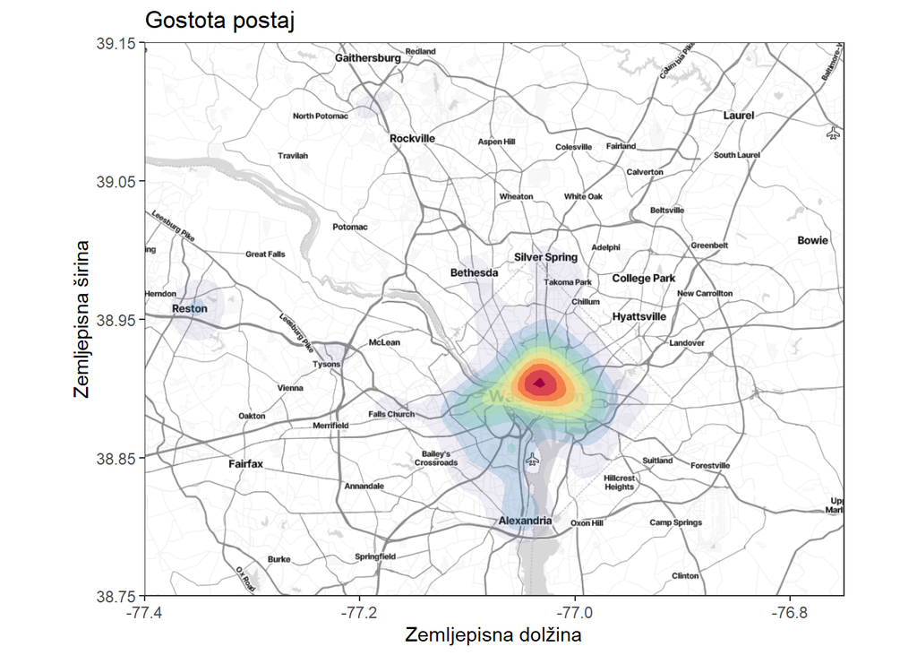

Čeprav je omrežje postaj zelo veliko, je gostota postaj največja v okolici centra Washington, D.C..

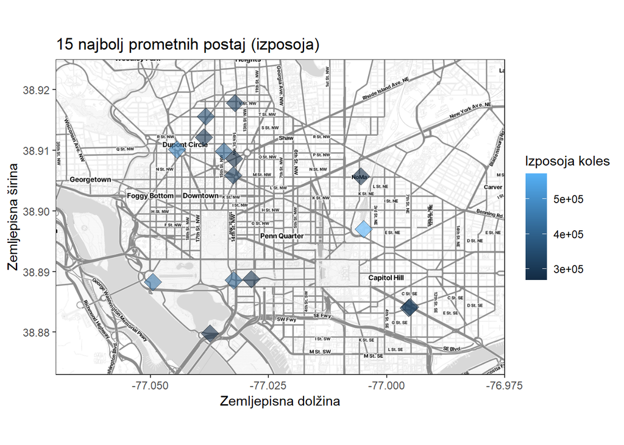

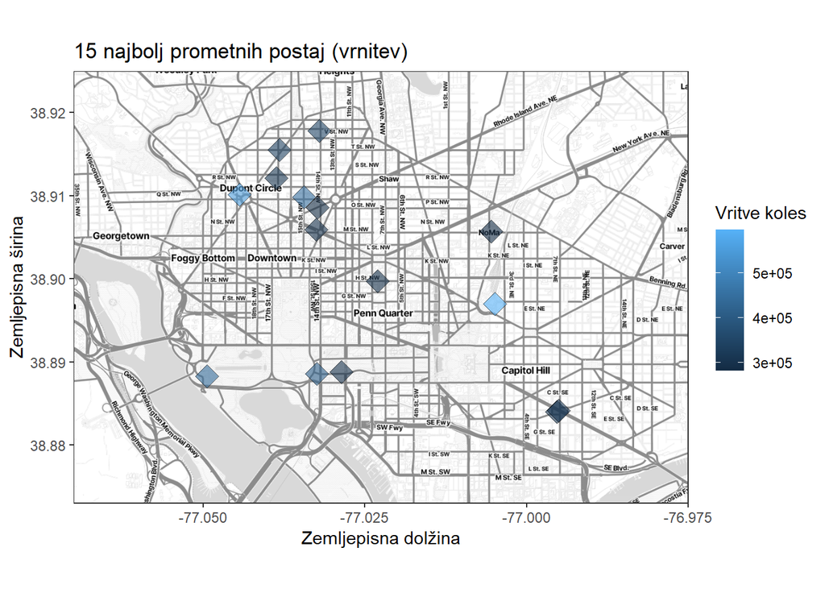

Petnajst najbolj promentih postaj se vse nahajajo v strogem centru. Opazimo, da se najbolj prometne postaje po izposoji in vrnitvi koles razlikujejo le v eni postaji. To pomeni, da je kolesarsko omrežje dobro uravnoteženo, saj so izposoje in vrnitve do neke mere simetrične.

## Napovedni model in prečno preverjanje

Iz zgornjih grafov je razvidno, da vreme in Covid-19 pomembno vplivata na število voženj. Poizkusimo ugotoviti katere spremenljivke bi vključili v naš napovedni model.

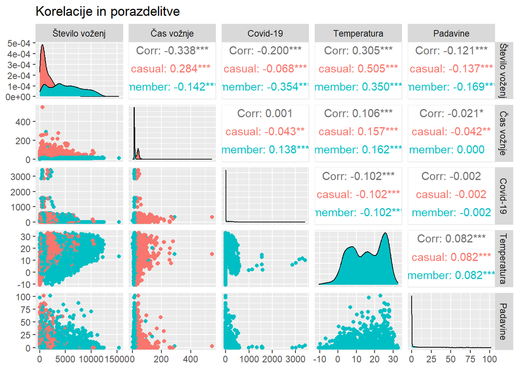

Kot smo sklepali že iz prejšnjih grafov imata tako vreme kot tudi Covid-19 vpliv na število voženj in čas voženj. Diagonalni elementi grafa nam kažejo porazdelitev spremenljivke. Ker se porazdelitve na graf slabo vidijo za Covid-19 in za padavine jih poglejmo se v posebnem primeru, ko so večje od nič.

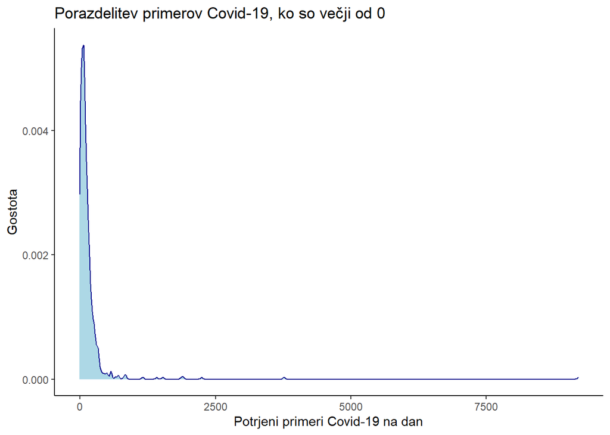

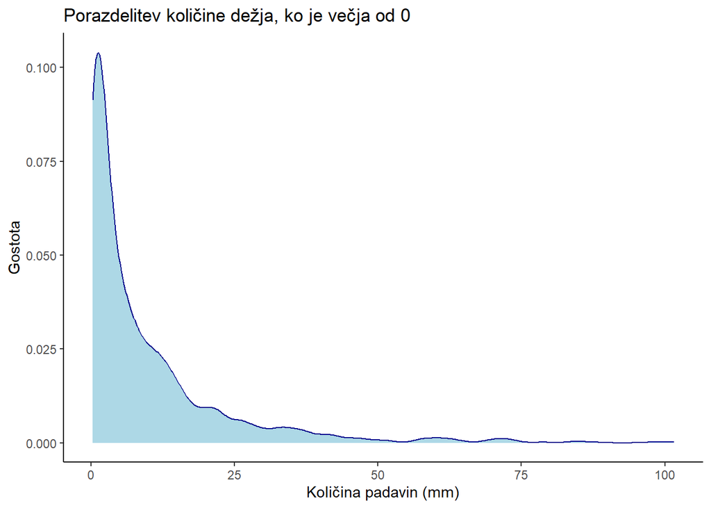

Iz dolgega repa porazdelitev vidimo, da je nekaj ekstremnih primerov, ko je število potrjenih primerov Covida-19 zelo veliko. Rep pri količini padavain je krajši, a vseeno nakazuje na nekaj primerov obilnih padavin.

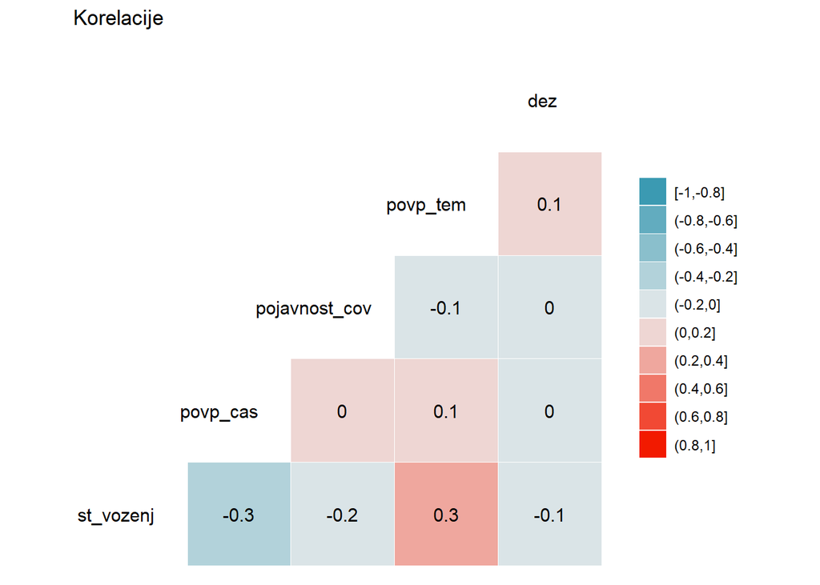

Še bolj pregleden način predstavitv korelacij, kjer ne delimo po tipu naročnine.

Sestavili bomo šest regresijskih modelov in poizkušali napovedati število voženj v dnevu. Prvi trije modeli so zgrajeni z vgrajeno funkcijo `lm`, zadnji trije pa z pomočjo naključnih gozdov iz paketa `ranger`.

- V modelih, ki imajo v imenu število 1 uporabljamo:
  - povprečno dnevno temperaturo.
- V modelih, ki imajo v imenu število 2 uporabljamo:
  - povprečno dnevno temperaturo
  - štirinajst dnevno pojavnost okužb
  - količino padavin
  - globino snega
  - vremenski indikator za snežni vihar
- V modelih, ki imajo v imenu število 3 uporabljamo vse spremenljivke, ki jih imamo na voljo

### 1. napovedni model: lin.model1a

```
##
## Call:
## lm(formula = n ~ tavg_aug, data = tblM1_ucni)
##
## Residuals:
##    Min     1Q Median     3Q    Max
##  -4901  -2107  -1048   1933  12296
##
## Coefficients:
##             Estimate Std. Error t value Pr(>|t|)
## (Intercept) 1764.720     69.437   25.41   <2e-16 ***
## tavg_aug     103.686      3.848   26.95   <2e-16 ***
## ---
## Signif. codes:  0 '***' 0.001 '**' 0.01 '*' 0.05 '.' 0.1 ' ' 1
##
## Residual standard error: 2888 on 6840 degrees of freedom
## Multiple R-squared:  0.09596,    Adjusted R-squared:  0.09582
## F-statistic:   726 on 1 and 6840 DF,  p-value: < 2.2e-16
```

### 2. napovedni model: lin.model2

```
##
## Call:
## lm(formula = n ~ tavg_aug + cases_incidence + prcp + snwd + wt09,
##     data = tblM2_ucni)
##
## Residuals:
##     Min      1Q  Median      3Q     Max
## -4835.5 -2184.0  -865.9  1873.1 11954.2
##
## Coefficients:
##                  Estimate Std. Error t value Pr(>|t|)
## (Intercept)     2156.3815    71.9041  29.990   <2e-16 ***
## tavg_aug          99.8794     3.8508  25.938   <2e-16 ***
## cases_incidence   -2.4844     0.1648 -15.074   <2e-16 ***
## prcp             -48.2395     3.7932 -12.717   <2e-16 ***
## snwd              -8.3527     3.4788  -2.401   0.0164 *
## wt09             470.6975  1623.9729   0.290   0.7719
## ---
## Signif. codes:  0 '***' 0.001 '**' 0.01 '*' 0.05 '.' 0.1 ' ' 1
##
## Residual standard error: 2809 on 6836 degrees of freedom
## Multiple R-squared:  0.1453, Adjusted R-squared:  0.1446
## F-statistic: 232.4 on 5 and 6836 DF,  p-value: < 2.2e-16
```

### 3. napovedni model: lin.model3

```
##
## Call:
## lm(formula = n ~ ., data = tblM3_ucni)
##
## Residuals:
##     Min      1Q  Median      3Q     Max
## -5628.2 -1237.2  -245.6  1273.2  9789.3
##
## Coefficients:
##                     Estimate Std. Error t value Pr(>|t|)
## (Intercept)        5.370e+02  1.313e+02   4.091 4.34e-05 ***
## month             -2.681e-01  7.458e+00  -0.036 0.971327
## member_typemember  3.588e+03  4.673e+01  76.787  < 2e-16 ***
## cases_total        8.322e-02  5.575e-03  14.928  < 2e-16 ***
## deaths_total      -5.780e+00  2.516e-01 -22.968  < 2e-16 ***
## cases_today       -1.683e-02  1.127e-01  -0.149 0.881239
## deaths_today      -1.366e+01  1.986e+01  -0.688 0.491723
## cases_incidence   -9.346e-01  1.855e-01  -5.039 4.79e-07 ***
## awnd              -2.334e+01  1.698e+01  -1.374 0.169372
## prcp              -3.200e+01  3.061e+00 -10.455  < 2e-16 ***
## snow              -4.642e+00  4.099e+00  -1.132 0.257526
## snwd              -9.796e+00  2.504e+00  -3.912 9.25e-05 ***
## tmax               7.160e+01  8.840e+00   8.100 6.46e-16 ***
## tmin              -3.345e+00  1.125e+01  -0.297 0.766299
## wt01              -1.034e+02  6.339e+01  -1.632 0.102803
## wt02              -4.039e+02  1.765e+02  -2.288 0.022165 *
## wt03              -1.826e+02  8.682e+01  -2.103 0.035462 *
## wt04               2.440e+02  2.553e+02   0.956 0.339246
## wt05              -4.162e+02  5.627e+02  -0.740 0.459564
## wt06               4.462e+02  3.262e+02   1.368 0.171482
## wt08              -9.031e+01  8.328e+01  -1.084 0.278235
## wt09               5.536e+02  1.211e+03   0.457 0.647480
## wt11              -1.092e+03  5.670e+02  -1.925 0.054248 .
## wt13              -6.234e+02  1.482e+02  -4.207 2.62e-05 ***
## wt14               1.578e+02  2.026e+02   0.779 0.436177
## wt15              -2.307e+01  8.221e+02  -0.028 0.977616
## wt16              -1.629e+03  1.116e+02 -14.596  < 2e-16 ***
## wt17               2.587e+02  8.252e+02   0.314 0.753888
## wt18              -2.776e+02  2.364e+02  -1.174 0.240373
## wt21              -5.913e+02  1.127e+03  -0.525 0.599721
## wt22              -2.967e+02  1.947e+03  -0.152 0.878894
## tavg_aug           4.180e+01  1.247e+01   3.351 0.000809 ***
## ---
## Signif. codes:  0 '***' 0.001 '**' 0.01 '*' 0.05 '.' 0.1 ' ' 1
##
## Residual standard error: 1932 on 6810 degrees of freedom
## Multiple R-squared:  0.5972, Adjusted R-squared:  0.5954
## F-statistic: 325.7 on 31 and 6810 DF,  p-value: < 2.2e-16
```

### 4. napovedni model ng.reg.model1

```
## Ranger result
##
## Call:
##  ranger(n ~ tavg_aug, tblM1_ucni)
##
## Type:                             Regression
## Number of trees:                  500
## Sample size:                      6842
## Number of independent variables:  1
## Mtry:                             1
## Target node size:                 5
## Variable importance mode:         none
## Splitrule:                        variance
## OOB prediction error (MSE):       8787361
## R squared (OOB):                  0.04723777
```

### 5. napovedni model: ng.reg.model2

```
## Ranger result
##
## Call:
##  ranger(n ~ tavg_aug + cases_incidence + prcp + snwd + wt09, tblM2_ucni)
##
## Type:                             Regression
## Number of trees:                  500
## Sample size:                      6842
## Number of independent variables:  5
## Mtry:                             2
## Target node size:                 5
## Variable importance mode:         none
## Splitrule:                        variance
## OOB prediction error (MSE):       7168572
## R squared (OOB):                  0.2227535
```

### 6. napovedni model: ng.reg.model3

```
## Ranger result
##
## Call:
##  ranger(n ~ ., tblM3_ucni)
##
## Type:                             Regression
## Number of trees:                  500
## Sample size:                      6842
## Number of independent variables:  31
## Mtry:                             5
## Target node size:                 5
## Variable importance mode:         none
## Splitrule:                        variance
## OOB prediction error (MSE):       2549966
## R squared (OOB):                  0.723522
```

Poglejmo sedaj napake modelov.

```
## # A tibble: 6 × 4
##   model  RMSE Rsquared   MAE
##   <chr> <dbl>    <dbl> <dbl>
## 1 lin1a 2938.   0.0854 2434.
## 2 lin2  2850.   0.139  2364.
## 3 lin3  1984.   0.583  1562.
## 4 ng1   3018.   0.0562 2511.
## 5 ng2   2706.   0.227  2270.
## 6 ng3   1646.   0.720  1291.
```

Izračunan napake imamo v obliki [Root-mean-square error (RMSE)](https://en.wikipedia.org/wiki/Root-mean-square_deviation), [Coefficient of determination (Rsquared)](https://en.wikipedia.org/wiki/Coefficient_of_determination) in [Mean absolute error (MAE)](https://en.wikipedia.org/wiki/Mean_absolute_error). Da bomo lažje videli napake narišemo graf.

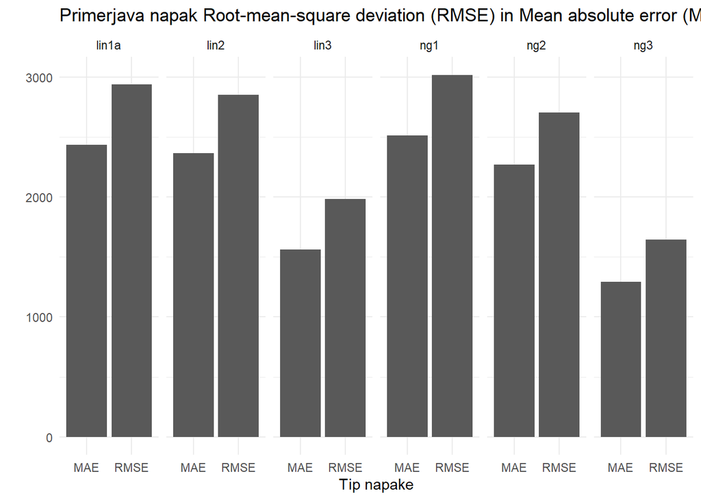

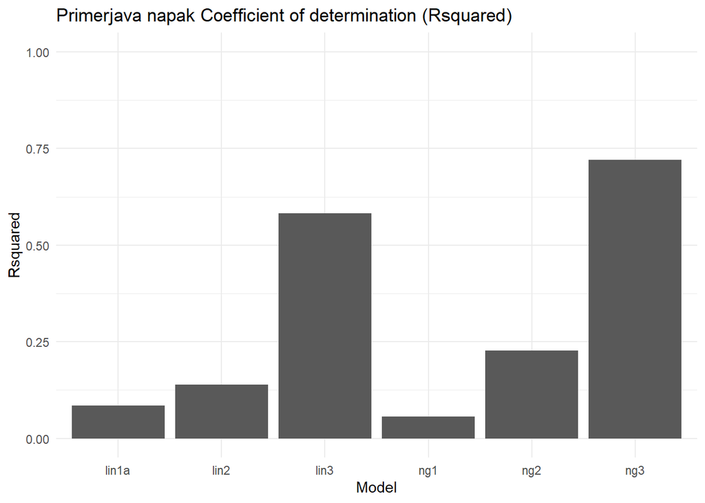

### Prečno preverjanje

Ocenimo še napovedano napako s prečnim preverjanjem.

#### lin.model1a

```
## [1] 8340394
```

#### lin.model2

```
## [1] 7902164
```

#### lin.model3

```
## [1] 3739212
```

#### ng.reg.model1

```
## [1] 8873179
```

#### ng.reg.model2

```
## [1] 7172786
```

#### ng.reg.model3

```
## [1] 2543318
```

## Razvrščanje v skupine

Poizkušimo razdeliti vreme v letu 2018 v skupine. Želimo si štiri skupine, ki bi v grobem ustrezale letnim časom. S pomočjo hierhičnega razvrščanja in metode k-tih voditeljev bomo poiskali optimalno število razbitja množice.

Najprej si poglejmo dendrogram.

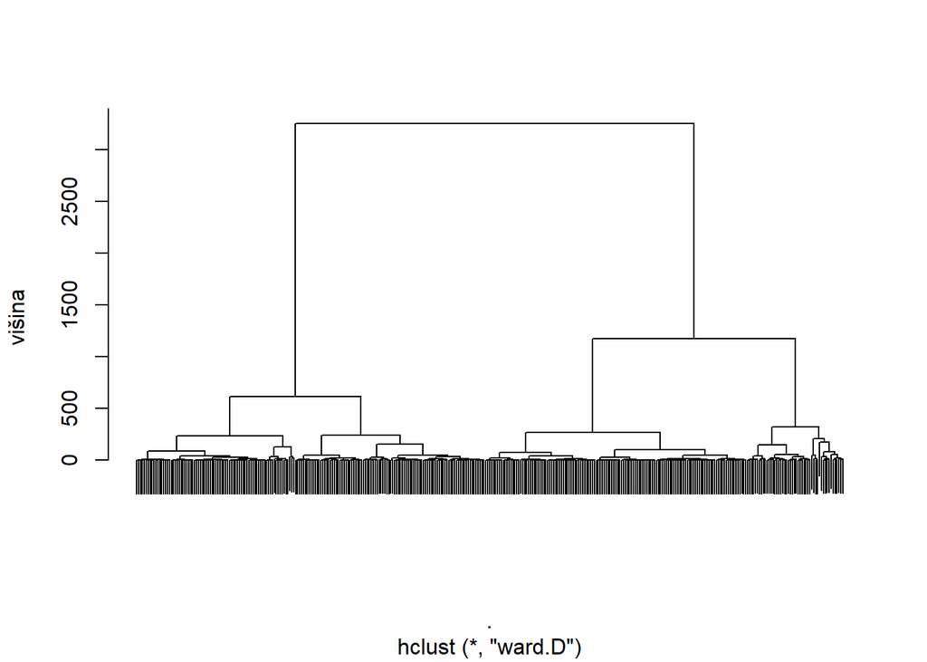

Zanima nas kako se spreminja razdalja med skupinami v vsakem koraku združevanja, zato si poglejmo sledeči graf.

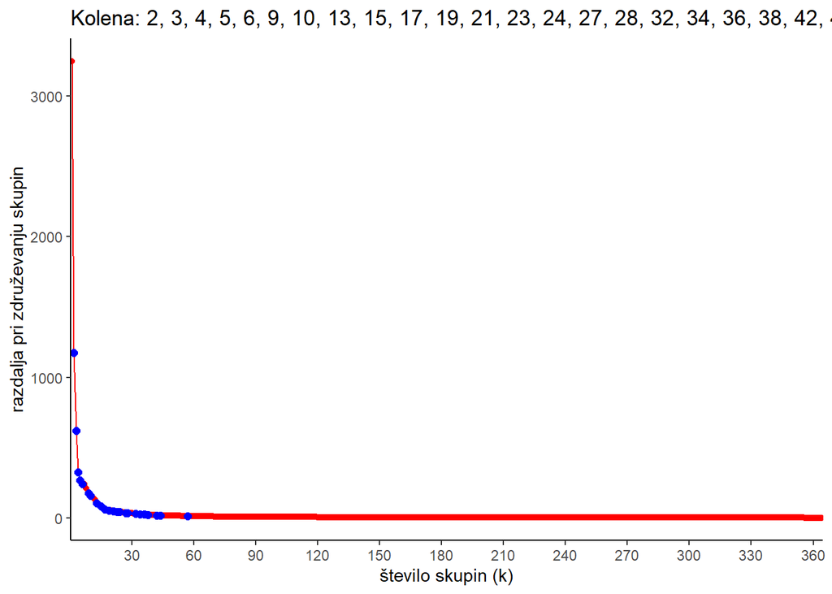

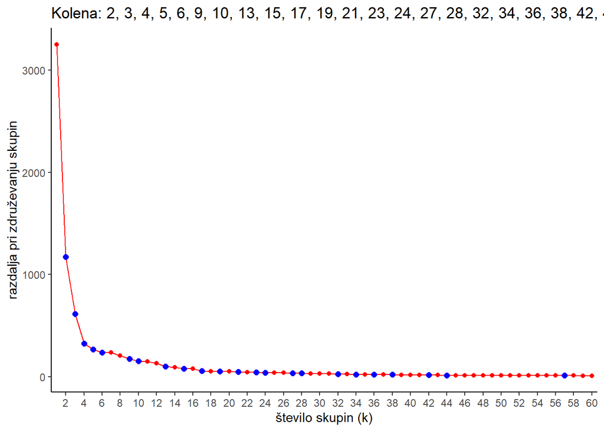

Zdaj vidimi, da so največje razlike ravno v skupinah 2,3 in 4.

### Hierarhično razvrščanje v skupine

Najprej si poglejmo diagram za izbiro optimalnega k z algoritomom hierhičnega razvrščanja

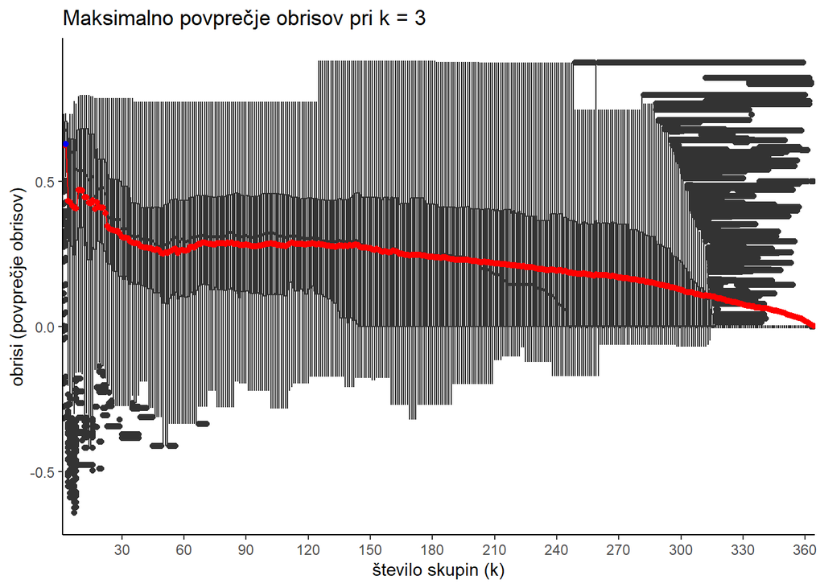

Če si diagram pogledamo pobližje vidimo, da je pri k = 3 izrazit padec.

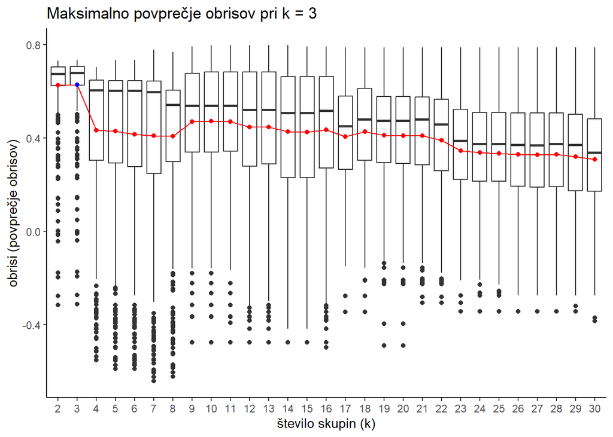

### Metoda k-tih voditeljev

Poglejmo si sedaj optimalni k, ki ga dobimo z metodo k-tih voditeljev.

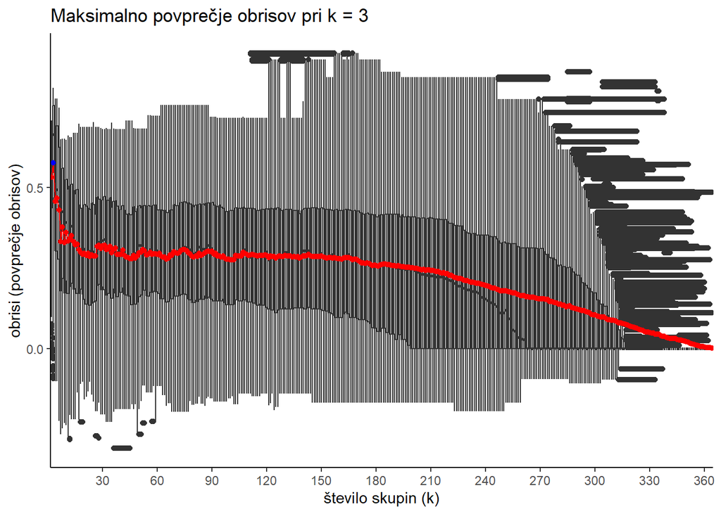

Poglejmo si ga pobližje.

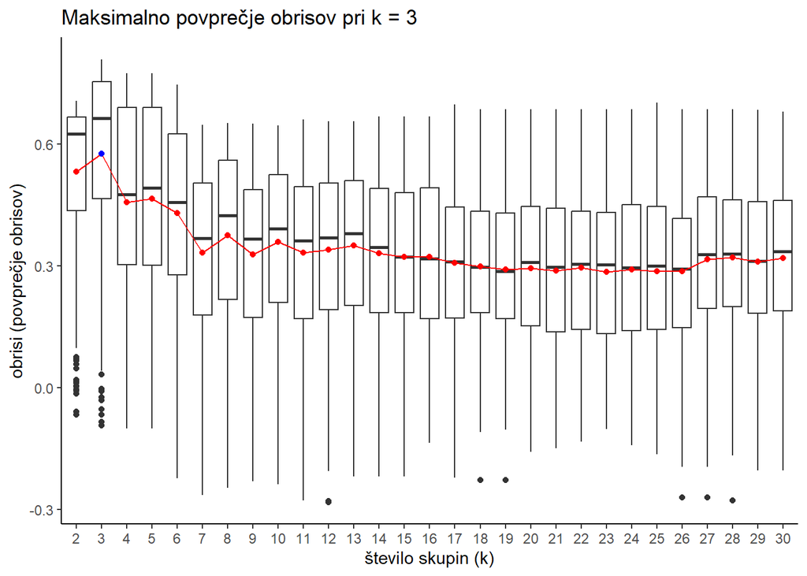

Ponovno je optimalni k = 3.

### Vizualizacija razbitja

Ker imajo naši podatki več kot dve rasežnosti smo jih prisiljeni preslikati v dvorasežni prostor. Pri tem seveda poskrbimo, da se razdalje med njimi kar se da ohranijo.

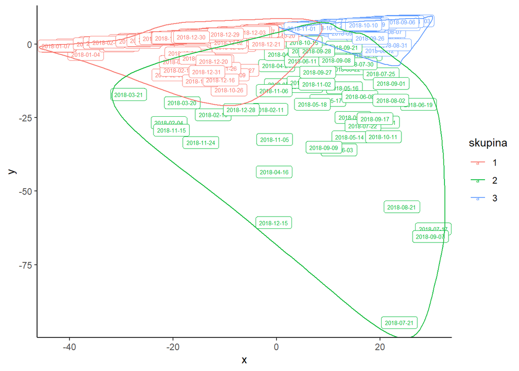

Naše razbitje nam ne poda dodatnega vpogleda v vremenske razmere v letu 2018. Brez dodatne analize nevemo kakšno vreme posamezne množice predstavljajo, vendar vidimo, da večina dnevov sledi premici, veliko manj pa jih je raztreščenih naokoli. Sklepamo, da je množica 2 množica izrednih vremenskih pojavov.

## Zaključek

Zaključimo lahko, da je število izposoj zelo povezano z vremenom in tudi z razmerjem pandemije Covid-19. Poudarimo, da se najverjetneje vpliv pandemije zmanjšuje s časom, saj se tako mi kot virus prilagajamo in spreminjamo.